本專案首要目標在於協助外交團體在接近國際組織時，能夠快速且有效地進行**議題設定**，並同時挖掘數個與該組織有**直接、間接互動關係**的推特帳號，作為初步的接近目標。林碧炤(2006)認為非傳統外交執行面上的面臨困境在於國際組織關注的議題錯綜複雜，加上台灣較缺乏國際訊息，難以得知國際組織的相關資訊，導致台灣外交組織往往不知該從哪些議題切入。筆者認為若能蒐集推特上的公開使用行為資料，分析國際組織的社群網絡，**進而在網絡結構中找到該組織關注的議題，以及有頻繁互動的對象**，將能提升非傳統外交中的線上外交，在制定策略時，議題設定的**精準性**以及尋找管道的**有效性**。

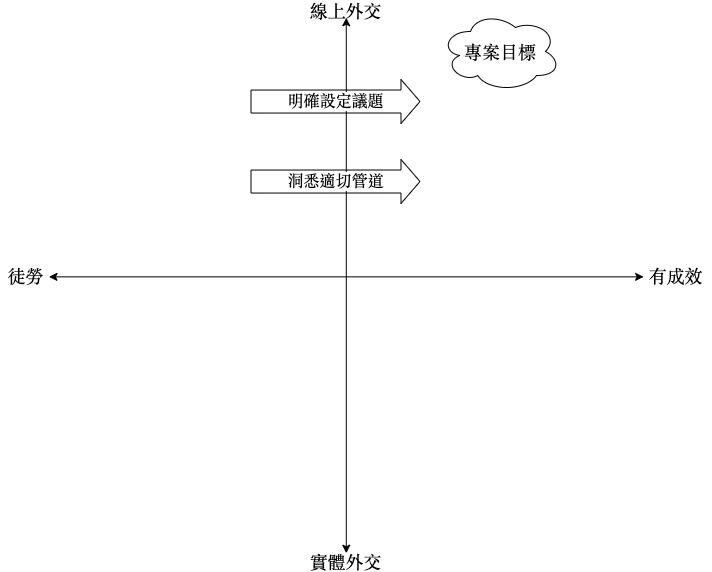

# 1. **如何達成有效的議題設定**

本研究分析目標國際組織推特帳號所跟隨(Follwoing)的帳號(以下簡稱為該國際組織的上線)，透過網絡結構將這些上線分類，並以資訊檢索的演算法對分類後的帳號自我介紹*進行分析，摘要出可能與各群組帳號相關的主題。接著進一步尋找這些上線帳號的跟隨名單中與台灣相關的帳號。至此研究預期的成效在於，若要透過某一議題觸及某一組織，首先可以設法觸及這些與台灣相關的帳號，詢問深入研究該議題前必要的先備資訊。

# 2. **如何確認國際組織在推特上的互動關係**

為了進一步確認與目標國際組織有**實質互動**關係的帳號，本研究也分析該組織在推文中有提及(Mention)過的帳號，研究的最終目標是透過**兩階段的提及關係**，也就是該組織提及過的帳號發文中，又有提過的帳號，從第二層的提及關係中找到與台灣相關的帳號，作為可能觸及目標組織的管道。本研究假設在推特上的提及行為，背後隱含兩種意義，首先是主動提及，也就是某一帳號透過提及行為，意圖與另一帳號產生聯繫；其次是被動提及，即某一帳號為了回應另一帳號的作為，進而在推特上使用提及的功能進行回覆。上述兩種作為，都可以視為使用者有意產生聯繫的結果*，因此筆者認為透過提及行為所發現的關係網絡，將會是接近某組織時可以利用的互動網絡基礎。

#### * 帳號自我介紹為推特上，使用者為自身帳號打的一段簡短描述

#### * 儘管有研究指出在政治性質的推特網絡中，提及行為不見得是友善的互動，時常參雜立場不同的政治勢力，透過提及對方的帳號，使自己的論述出現在對方的版面(Bruns & Highfield, 2013)。但本研究假設國際組織在推特上的使用行為應和政治網絡相異，筆者在研究過程中也未看見資料有透過提及某一帳號進行論戰的行為。

#### 1. 林碧炤（2006）：台灣的非傳統外交，戰略安全研析，10: 7-15。

#### 2. Bruns, A., & Highfield, T. (2013). Political networks on Twitter: Tweeting the Queensland state election. Information, Communication & Society, 16(5), 667-691.